# Web Maps in R with Leaflet

3/8/2018

## Web Maps in R with Leaflet

Welcome! While we're waiting:

[interactive chart not shown]

## Introduction

## Outline

- Setup
- SF Property Maps
  - Intro to Leaflet
  - Markers and Popups
  - Color coding
  - Legends
- Mapping data
  - Polygons
  - Icons
  - Background
- Sharing your work

*(hint: press w to view slideshow in wide mode)*

## Setup

This workshop/tutorial will walk you through the basics of using the Leaflet mapping package in R. You can follow along in any of the three formats:

- *Tutorial Page* (mapping-in-r.html)
- *Raw code* (mapping-in-R-RAW.html or mapping-in-R-RAW.Rmd)
- *Slides* (mapping-in-r-slides.html)

To begin, lets set up our packages and environment.

## Installing packages

To install Leaflet, use the following command `install.packages("leaflet")`. We will be using other packages in this tutorial. If you don't already have any of the following packages installed, you can use this code to do so:

```r
# install.packages("leaflet")
# install.packages("RColorBrewer")
# install.packages("rgdal")
# install.packages("magrittr")
```

## Loading packages

You only instal a package once, but each time you want to use it, you have to load it with `library()`

```r
library(leaflet)
library(RColorBrewer)
library(rgdal)
#library(magrittr)
```

## Set working directory

## setwd("~/Documents/Dlab/workshops/2018/rleaflet")

[figure not shown]

## Our First Leaflet Map

## Our first Leaflet map

```r
map1 <- leaflet()       # Initialize the map object
map1 <- addTiles(map1)  # Add basemap tiles
map1                    # Display the map
```

## Our first Leaflet map

[interactive chart not shown]

## Setting the view

Note, we are adding to an exisiting `map1`

```r
map1 <- setView(map1, lat=37.870044, lng=-122.258169, zoom = 15)
map1
```

## Setting the view

[interactive chart not shown]

## Piping Syntax

**Requires `dplyr` or `magrittr` package to be loaded**

```r
map2 <- leaflet() %>%
        addTiles() %>%
        setView(lat=37.870044, lng=-122.258169, zoom = 15)
map2
```

## Piping gives us the same map

```r
map2
```

[interactive chart not shown]

## Syntax Comparison

**Regular**

```
map1 <- leaflet()
map1 <- addTiles(map1)
map1 <- setView(map1, lat=37.870044, lng=-122.258169, zoom = 15)
map1
```

**Piping**

[output not shown]

### WARNING: Don't name your map object `map`

## Challenge

Rerun the `piping` code changing the zoom level

- What zoom level reveals the campus building that the map is centered on?
- What zoom level shows all of berkeley?
- What is the max/min zoom level that returns a basemap?

## Changing the basemap

There are a number of freely availble basemaps that you can add to your leaflet map instead of using the default OpenStreetMap tiles.

You can customize the basemap with the `addProviderTiles` function

Check out the documentation

```
?addProviderTiles
```

And open the web page of available basemaps

http://leaflet-extras.github.io/leaflet-providers/preview/

## Now try a few

Here's the syntax - instead of using `addTiles` you use `addProviderTiles`

```r
map2 <- leaflet() %>%
        addProviderTiles("Esri.WorldStreetMap") %>%
        setView(lat=37.870044, lng=-122.258169, zoom = 12)
```

## View it

```r
map2
```

[interactive chart not shown]

## Add Your own map

Source: https://mapwarper.net/maps/25477#Preview_tab

```r
mapurl <- "https://mapwarper.net/maps/tile/25477/{z}/{x}/{y}.png"

map2 <- leaflet() %>%
  addProviderTiles("CartoDB.Positron") %>%
  addTiles(mapurl) %>%  # custom
  setView(lat=37.870044, lng=-122.258169, zoom = 13)
```

### Here we are combining `addTiles` and `addProviderTiles`

## Add a non-provider map

```r
map2
```

[interactive chart not shown]

## Questions?

## Mapping Data

## Add Data with a Marker

Note that the `setView` function is commented out.

```r
map2 <- leaflet() %>%
  addTiles() %>%  # Add default OpenStreetMap map tiles
  #setView(lat=37.870044, lng=-122.258169, zoom = 17) %>%
  addMarkers(lat=37.870044, lng=-122.258169, popup="Go Bears!")
```

## Add Data with a Marker

```r
map2  # Display the map  - Click on the marker
```

[interactive chart not shown]

## Mapping Data Sets

## The Sample Data

**San Francisco Open Data Portal** https://data.sfgov.org

[SF Property Tax Rolls](https://data.sfgov.org/Housing-and-Buildings/Assessor-Historical-Secured-Property-Tax-Rolls/wv5m-vpq2)

This data set includes the Office of the Assessor-Recorder’s secured property tax roll spanning from 2007 to 2016.

We are using this as a proxy for home values.

We are working with a simplified sample of the full data set.

## Load the CSV file into a data frame

*Set your working directory first to the folder where you downloaded the workshop files!*

```r
sfhomes <- read.csv('data/sfhomes15.csv', stringsAsFactors = FALSE)
str(sfhomes)
```

```
## 'data.frame':    680 obs. of  11 variables:
##  $ SalesDate   : chr  "2015-08-21" "2015-08-13" "2015-12-29" "2015-07-06" ...
##  $ Address     : chr  "0000 2760 19TH                AV0015" "0000 0560AMISSOURI            ST0000" "0000 0718 LONG BRIDGE         ST1202" "0000 0899 VALENCIA            ST0202" ...
##  $ YrBuilt     : int  1979 2003 2016 2015 1961 1900 2015 NA 1947 1907 ...
##  $ NumBeds     : int  2 2 2 3 3 2 2 0 0 3 ...
##  $ NumBaths    : int  2 2 2 3 3 2 2 0 0 3 ...
##  $ NumUnits    : int  1 1 1 1 1 1 1 1 1 1 ...
##  $ AreaSqFt    : int  1595 1191 1346 1266 1840 1256 1520 536 950 1837 ...
##  $ Neighborhood: chr  "Twin Peaks" "Potrero Hill" "Mission Bay" "Mission" ...
##  $ Value       : int  865000 1402560 2260993 1700000 2309692 2700564 1925000 583768 944180 1750001 ...
##  $ lat         : num  37.7 37.8 37.8 37.8 37.8 ...
##  $ lon         : num  -122 -122 -122 -122 -122 ...
```

## Explore the data

```r
head(sfhomes)
```

```
##    SalesDate                              Address YrBuilt NumBeds NumBaths
## 1 2015-08-21 0000 2760 19TH                AV0015    1979       2        2
## 2 2015-08-13 0000 0560AMISSOURI            ST0000    2003       2        2
## 3 2015-12-29 0000 0718 LONG BRIDGE         ST1202    2016       2        2
## 4 2015-07-06 0000 0899 VALENCIA            ST0202    2015       3        3
## 5 2015-06-12 0000 1333 JONES               ST0808    1961       3        3
## 6 2015-04-14 0000 1904 BAKER               ST0000    1900       2        2
##   NumUnits AreaSqFt    Neighborhood   Value      lat       lon
## 1        1     1595      Twin Peaks  865000 37.73601 -122.4741
## 2        1     1191    Potrero Hill 1402560 37.75920 -122.3965
## 3        1     1346     Mission Bay 2260993 37.77181 -122.3942
## 4        1     1266         Mission 1700000 37.75876 -122.4210
## 5        1     1840        Nob Hill 2309692 37.79362 -122.4149
## 6        1     1256 Pacific Heights 2700564 37.78881 -122.4437
```

## Map the data

```r
map4 <- leaflet() %>%
  addTiles() %>%
  addMarkers(lat=as.numeric(sfhomes$lat), lng=as.numeric(sfhomes$lon),
            popup= paste("Address:", sfhomes$Address,
                         "<br>",
                         "Property Value: ", sfhomes$Value))
```

## Map the data

```r
map4    # Thoughts?
```

[interactive chart not shown]

## Popups Made Easier

We can save the popup code as a string and re-use it instead of typing it over and over again.

- Note a little HTML knowledge can go a long way!

```r
popup_content <- paste("<b>Address:</b>", sfhomes$Address,"<br>",
                       "<b>Property Value</b>: ", sfhomes$Value, "<br>",
                       "<b>Neighborhood:</b> ", sfhomes$Neighborhood, "<br>",
                       "<b>Num Bedrooms: </b>", sfhomes$NumBeds, "<br>",
                       "<b>Num Bathrooms:</b>", sfhomes$NumBaths
                       )
```

## Map the data

You can see here that we are also using some shorthand syntax

- By passing in the name of the data object to `leaflet` we can reference column values directly.
- Note also that we are using the `tilde` operator to map the data to the addMarkers function.
- When lng and lat are not named (e.g. `lng=lon`) then they must be in the expected order (lng, lat).

```r
map4 <- leaflet(sfhomes) %>%
  addTiles() %>%
  addMarkers(~lon, ~lat, popup = ~popup_content)
  #addMarkers(sfhomes$lon, sfhomes$lat, popup = ~popup_content)
```

## Map the data

```r
map4   # - check out the popups now
```

[interactive chart not shown]

## Dig deeper

The map is too crowded with Markers.

Read the `addMarker` documentation for options to address this.

```r
addMarkers(map, lng = NULL, lat = NULL, layerId = NULL, group = NULL,
           icon = NULL, popup = NULL, options = markerOptions(),
           clusterOptions = NULL, clusterId = NULL,
           data = getMapData(map))
```

## Cluster Option

```r
map4 <- leaflet(sfhomes) %>%
  addTiles() %>%
  addMarkers(~lon, ~lat, popup= popup_content,
            clusterOptions = 1)
```

## Cluster Option

```r
map4  # Explore the Map - hover over a cluster marker, zoom in.
```

[interactive chart not shown]

## Mapping Points as Circles

`addCirleMarker`

```r
map4 <- leaflet(sfhomes) %>%
  addTiles() %>%
  addCircleMarkers(~lon, ~lat, popup = popup_content)
```

## Mapping Points as Circles

`addCirleMarker`

```r
map4
```

[interactive chart not shown]

## addCircleMarkers

```r
addCircleMarkers(map, lng = NULL, lat = NULL, radius = 10, layerId = NULL,
    group = NULL, stroke = TRUE, color = "#03F", weight = 5, opacity = 0.5,
    fill = TRUE, fillColor = color, ....)
```

## Customize the circleMarkers

Change color, radius and stroke weight of circle markers

- Use `colors()` to see a list of all R named colors.
- You can expand on these with [hexidecimal color values](http://www.color-hex.com).

```r
map4 <- leaflet(sfhomes) %>%
  addTiles() %>%
  addCircleMarkers(~lon, ~lat, popup = popup_content,
             color="white", radius=6, weight=2,   # stroke
             fillColor="red",fillOpacity = 0.75   # fill
             )
```

## Customize the circleMarkers

```r
map4
```

[interactive chart not shown]

## Data Driven Symbology

## Cartography

Art + Science

Finding the right symbology - size, color, shape, etc

and mapping it to your data

Often requires a classification scheme

## Mapping Points by Size

We can symbolize the size of points by data values by making the radius of the circle a function of the data value.

```r
map4 <- leaflet(sfhomes) %>%
  addProviderTiles("CartoDB.Positron") %>%
  addCircleMarkers(~lon, ~lat, popup=popup_content,
             fillColor= NA,
             radius= ~NumBeds+2, color="Red", weight=1, fillOpacity = 0
             )
```

## Mapping Points by Size

```r
map4
```

[interactive chart not shown]

## addCircles vs addCircleMarkers

Circles and Circle Markers look quite similar.

Circle radii are specified in meters while Circle Markers are specified in pixels.

```r
map4 <- leaflet(sfhomes) %>%
  addProviderTiles("CartoDB.Positron") %>%
  addCircles(~lon, ~lat, popup=popup_content,
             fillColor= NA,
             radius= ~NumBeds*10, color="Red", weight=1, fillOpacity = 0
             )
```

```r
map4
```

[interactive chart not shown]

## Mapping Data by Color

## Color Palettes

Sets of colors

R has some preloaded named color palette functions from the `grDevices` package

- rainbow, topo.colors, terrain.colors, heat.colors

```r
rainbowcols <- rainbow(5)  # Create a palette of 5 colors
rainbowcols                         # Take a look
hist(as.numeric(sfhomes$NumBeds),   # Create a histogram
 col = rainbowcols)                 #      using these colors
```

## Color Palettes

```
## [1] "#FF0000FF" "#CCFF00FF" "#00FF66FF" "#0066FFFF" "#CC00FFFF"
```

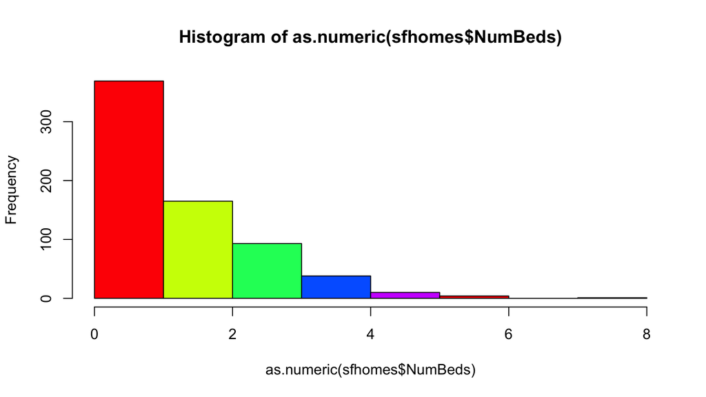

## RColorBrewer

The RColorBrewer package is widely used to create color palettes for maps.

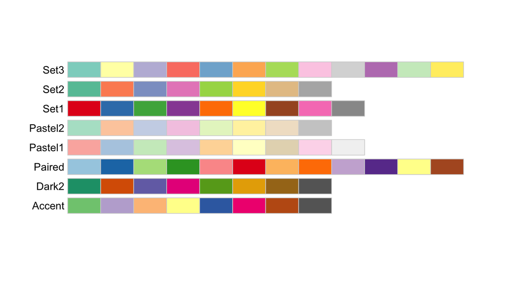

```r
#display.brewer.all()
display.brewer.all(type="qual")
```

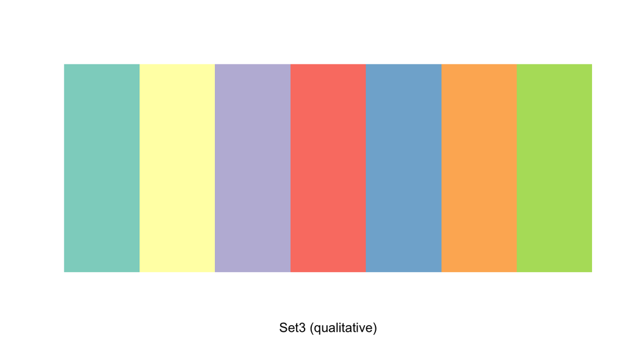

```r
#display.brewer.all(type="seq")
#display.brewer.all(type="div")
display.brewer.pal(7, "Set3" )  # Try a different number of colors
```

## Color Mapping in leaflet

```r
# colorFactor maps factors to colors.
colorFactor(palette, domain, levels = NULL, ordered = FALSE,
  na.color = "#808080", alpha = FALSE, reverse = FALSE)

# colorNumeric -a simple linear mapping of numeric data to color palette
colorNumeric(palette, domain, na.color = "#808080", alpha = FALSE,
  reverse = FALSE)
```

## Color Mapping in leaflet

```r
# colorBin also maps numeric data,
# but performs binning based on value (see the cut function).
colorBin(palette, domain, bins = 7, pretty = TRUE,
         na.color = "#808080", alpha = FALSE, reverse = FALSE)

# colorQuantile similarly bins numeric data, but with quantile function.
colorQuantile(palette, domain, n = 4,
  probs = seq(0, 1, length.out = n + 1),
  na.color = "#808080", alpha = FALSE, reverse = FALSE)
```

## Mapping Categories

## Map Homes by Neighborhood

- with the Leaflet `colorFactor` function
- Check out the available RColorBrewer palettes first

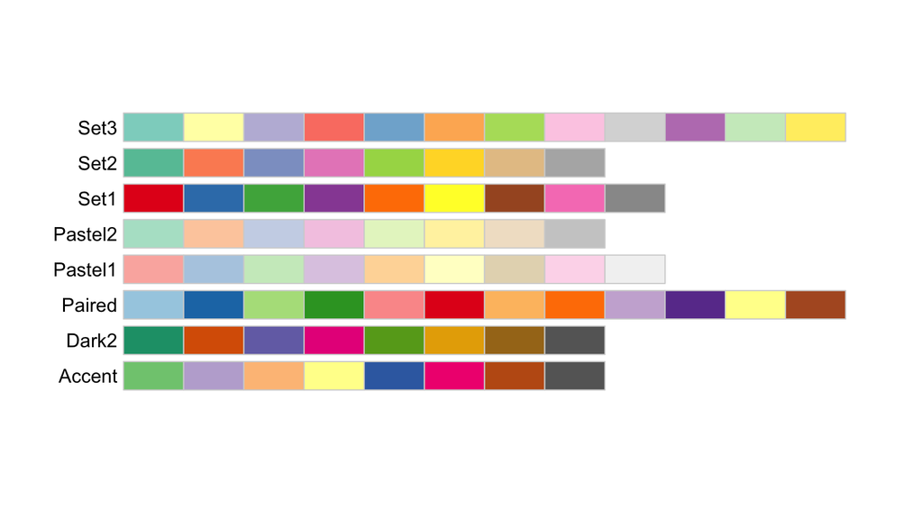

```r
display.brewer.all(type="qual")
```

## colorFactor

`colorfactor` takes as input a color palette and a data object (domain) that contains the full range of possible values to be mapped.

`colorfactor` returns a function specific to that domain that can be used to output a range of color values.

```r
# Create a qualitative color palette
myColors <- colorFactor("Paired", sfhomes$Neighborhood)
```

## Test it

```r
the_color_values <- myColors(sfhomes$Neighborhood)
length(the_color_values)
```

```
## [1] 680
```

```r
length(the_color_values) == length(sfhomes$Neighborhood)
```

```
## [1] TRUE
```

```r
unique(the_color_values)
```

```
##  [1] "#B15928" "#C4AAD2" "#E83F26" "#F57166" "#FBAE63" "#F6905B" "#3EA433"
##  [8] "#BFA19E" "#EDD279" "#4F8EC1" "#9BD277" "#FF9939" "#A6CEE3" "#7E54A6"
## [15] "#79A6A3" "#C3A176"
```

## Homes by Neighborhood

Using a color palette

```r
map4 <- leaflet(sfhomes) %>%
  addProviderTiles("CartoDB.Positron") %>%
  addCircleMarkers(~lon, ~lat,
             popup= popup_content,
             fillColor= ~myColors(Neighborhood),
             radius=6, color=NA, weight=2, fillOpacity = 1
             )
```

## Homes by Neighborhood

```r
map4  # what neighborhood had the most sales?
```

[interactive chart not shown]

## Add a Legend

## Add a Legend

```r
map4 <- leaflet(sfhomes) %>%
  addProviderTiles("CartoDB.Positron") %>%
  addCircleMarkers(~lon, ~lat, popup=popup_content,
             fillColor= ~myColors(Neighborhood),
             radius=6, color=NA, weight=2,fillOpacity = 1
             ) %>%
      addLegend(title = "Neighborhood", pal =  myColors,
                values = ~Neighborhood, opacity = 1,
                position="bottomleft")
```

## Add a legend

```r
map4
```

[interactive chart not shown]

## Mapping Colors to Numeric Values

For simple linear scaling of colors to values use `colorNumeric`

```r
#display.brewer.all(type="seq")
numColors <- colorNumeric("Reds", sfhomes$Value)
```

## Proportional Color Map

```r
map4 <- leaflet(sfhomes) %>%
  addProviderTiles("CartoDB.Positron") %>%
  addCircleMarkers(~lon, ~lat, popup=popup_content,
             fillColor= ~numColors(Value),
             radius=6, color="grey", weight=1, fillOpacity = 1
             ) %>%
      addLegend(title = "Property Values", pal =  numColors,
                values = ~Value, opacity = 1,
                position="bottomleft")
```

```r
map4
```

[interactive chart not shown]

## Quantile Colors

You can use `colorQuantile` to create a color palette based on quantiles

`?colorQuantile`

Default is 4 bins, but you can set n manually (3 to 7)

```r
#display.brewer.all(type="div")
quantColors <- colorQuantile("Reds", sfhomes$Value, n=5)

map4 <- leaflet(sfhomes) %>%
  addProviderTiles("CartoDB.Positron") %>%
  addCircleMarkers(~lon, ~lat, popup=popup_content,
             fillColor= ~quantColors(Value),
             radius=6, color="grey", weight=1,fillOpacity = 1
             )
```

```r
map4
```

[interactive chart not shown]

```r
map4 %>%  addLegend(title = "Value", pal =  quantColors,
                values = ~Value, opacity = 1,
                position="bottomleft")
```

[interactive chart not shown]

```r
map5 <-map4 %>%   addLegend(pal = quantColors, values = ~Value,
                     title = "Property Value, 2015",
                     position="bottomleft",
                     opacity=1,
                     labFormat = function(type, cuts, p) {
                      n = length(cuts)
                      cuts = paste0("$", format(cuts[-n], big.mark=","),
                                  " - ", "$",format(cuts[-1], big.mark=","))
                      }
                   )
```

```r
map5
```

[interactive chart not shown]

## Data Order

*What's happening here?*

```r
sfhomes_low2high <- sfhomes[order(sfhomes$Value, decreasing = FALSE),]

map4 <- leaflet(sfhomes_low2high) %>%
  addProviderTiles("CartoDB.Positron") %>%
  addCircleMarkers(~lon, ~lat, popup=popup_content,
             fillColor= ~quantColors(Value),
             radius=6, color="grey", weight=1,fillOpacity = 1
             )
```

Does the output map look different from previous map?

```r
map4
```

[interactive chart not shown]